# Análisis Descriptivo con `data.table` y `DataExplorer` usando `mtcars`

Ricardo Macías Bohórquez

21 de October de 2024

# Análisis Descriptivo con `data.table` y `DataExplorer` usando `mtcars`

En este análisis, exploraremos el conjunto de datos `mtcars`, un conjunto de datos clásico en R que contiene especificaciones sobre varios modelos de automóviles. A través de este análisis, aprenderemos a calcular estadísticas descriptivas, explorar relaciones entre variables con correlaciones, y visualizar los datos con técnicas gráficas como histogramas, boxplots y violinplots.

## 1. Descripción de la base de datos `mtcars`

El conjunto de datos `mtcars` contiene 32 observaciones (automóviles) y 11 variables numéricas que describen diferentes aspectos de rendimiento y características de los autos.

### Variables de `mtcars`:

- **mpg**: Millas por galón (mileage).
- **cyl**: Número de cilindros.
- **disp**: Desplazamiento del motor (pulgadas cúbicas).
- **hp**: Caballos de fuerza.
- **drat**: Relación del eje trasero.
- **wt**: Peso del automóvil (en miles de libras).
- **qsec**: Tiempo en segundos para recorrer un cuarto de milla.
- **vs**: Tipo de motor (0 = V-shaped, 1 = straight).
- **am**: Tipo de transmisión (0 = automática, 1 = manual).
- **gear**: Número de velocidades de la transmisión.
- **carb**: Número de carburadores.

## 2. Exploración de Datos con `DataExplorer`

### 2.1 Cargar los datos y generar un reporte exploratorio

Vamos a generar un reporte inicial usando `DataExplorer`, que nos proporcionará una visión general de las variables en el conjunto de datos.

```r
# Cargar bibliotecas
library(data.table)
library(DataExplorer)

# Convertir mtcars a data.table
dt_mtcars <- as.data.table(mtcars)

# Generar un reporte automático
create_report(dt_mtcars)
```

```
##
##
## processing file: report.rmd
```

[output not shown]

```
## output file: C:/Users/rmaci/OneDrive/Documentos/Diplomados/Diplomado DPS UNAL/Sesiónes/Sesion_4/report.knit.md
```

[output not shown]

```
##
## Output created: report.html
```

**Explicación**: El reporte incluye la distribución de cada variable numérica, un análisis de datos faltantes, y la matriz de correlación entre las variables.

## 3. Estadísticas Descriptivas

### 3.1 Cálculo de estadísticas descriptivas básicas

Podemos calcular la media, mediana y desviación estándar de variables clave como `mpg` (millas por galón), `hp` (caballos de fuerza) y `wt` (peso del automóvil).

```r
# Calcular estadísticas descriptivas
estadisticas_mtcars <- dt_mtcars[, .(
  Media_mpg = mean(mpg),
  Mediana_mpg = median(mpg),
  Desviacion_mpg = sd(mpg),
  Media_hp = mean(hp),
  Mediana_hp = median(hp),
  Desviacion_hp = sd(hp),
  Media_wt = mean(wt),
  Mediana_wt = median(wt),
  Desviacion_wt = sd(wt)
)]
print(estadisticas_mtcars)
```

```
##    Media_mpg Mediana_mpg Desviacion_mpg Media_hp Mediana_hp Desviacion_hp
##        <num>       <num>          <num>    <num>      <num>         <num>
## 1:  20.09062        19.2       6.026948 146.6875        123      68.56287
##    Media_wt Mediana_wt Desviacion_wt
##       <num>      <num>         <num>
## 1:  3.21725      3.325     0.9784574
```

**Explicación**: - **Media**: Promedio de los valores de la variable. - **Mediana**: Valor central de los datos. - **Desviación estándar**: Mide la dispersión de los datos respecto a la media.

Por ejemplo, `mpg` mide la eficiencia de combustible en millas por galón. Conocer la media y la desviación estándar de esta variable nos da una idea de cuán eficiente es en promedio y cuánto varía entre los automóviles.

## 4. Análisis de Correlación

### 4.1 ¿Qué es la correlación?

La **correlación** mide la relación entre dos variables numéricas. El coeficiente de correlación de Pearson toma valores entre -1 y 1: - **1**: Correlación positiva perfecta (ambas variables aumentan juntas). - **-1**: Correlación negativa perfecta (una variable aumenta mientras la otra disminuye). - **0**: No hay relación lineal.

### 4.2 Calcular la matriz de correlación

Calculamos la correlación entre variables importantes como `mpg`, `hp`, `wt`, y `qsec`:

```r
# Calcular la matriz de correlación
correlacion_mtcars <- cor(dt_mtcars[, .(mpg, hp, wt, qsec)])
print(correlacion_mtcars)
```

```
##             mpg         hp         wt       qsec
## mpg   1.0000000 -0.7761684 -0.8676594  0.4186840
## hp   -0.7761684  1.0000000  0.6587479 -0.7082234
## wt   -0.8676594  0.6587479  1.0000000 -0.1747159
## qsec  0.4186840 -0.7082234 -0.1747159  1.0000000
```

**Explicación**: Esta matriz muestra cómo se relacionan las variables entre sí. Por ejemplo, podríamos observar una correlación negativa entre `mpg` y `wt`, lo que indica que a mayor peso del automóvil, menor es la eficiencia de combustible.

### 4.3 Visualizar la matriz de correlación

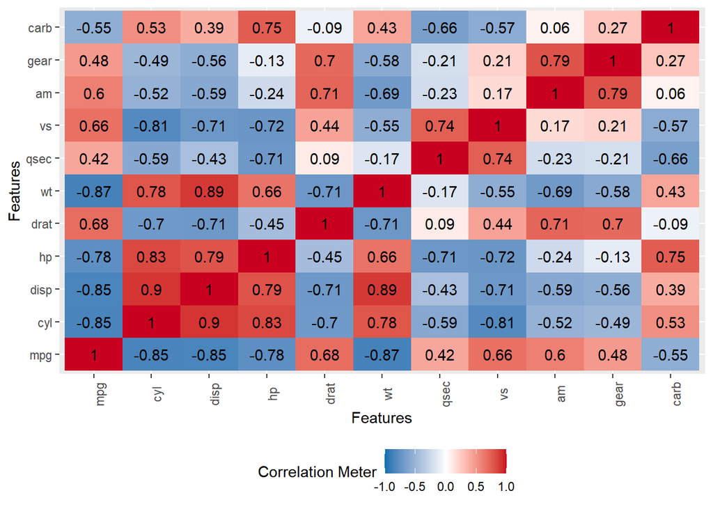

```r
# Visualizar la matriz de correlación
plot_correlation(dt_mtcars)
```

**Explicación**: Esta gráfica facilita la interpretación de las correlaciones, mostrando qué pares de variables tienen relaciones fuertes (positivas o negativas).

## 5. Visualización de Datos

### 5.1 Diagramas de caja (Boxplots)

Un **boxplot** es una herramienta útil para visualizar la distribución de una variable numérica y detectar posibles valores atípicos. Muestra el rango intercuartílico (IQR), los valores extremos (outliers), y la mediana.

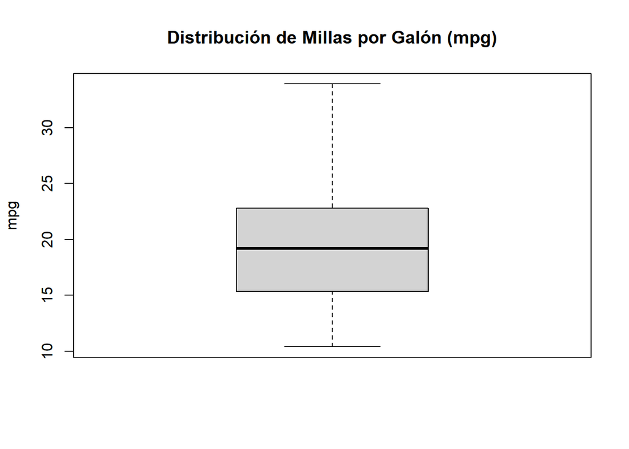

```r
# Boxplot de millas por galón (mpg)
boxplot(dt_mtcars$mpg, main = "Distribución de Millas por Galón (mpg)", ylab = "mpg")
```

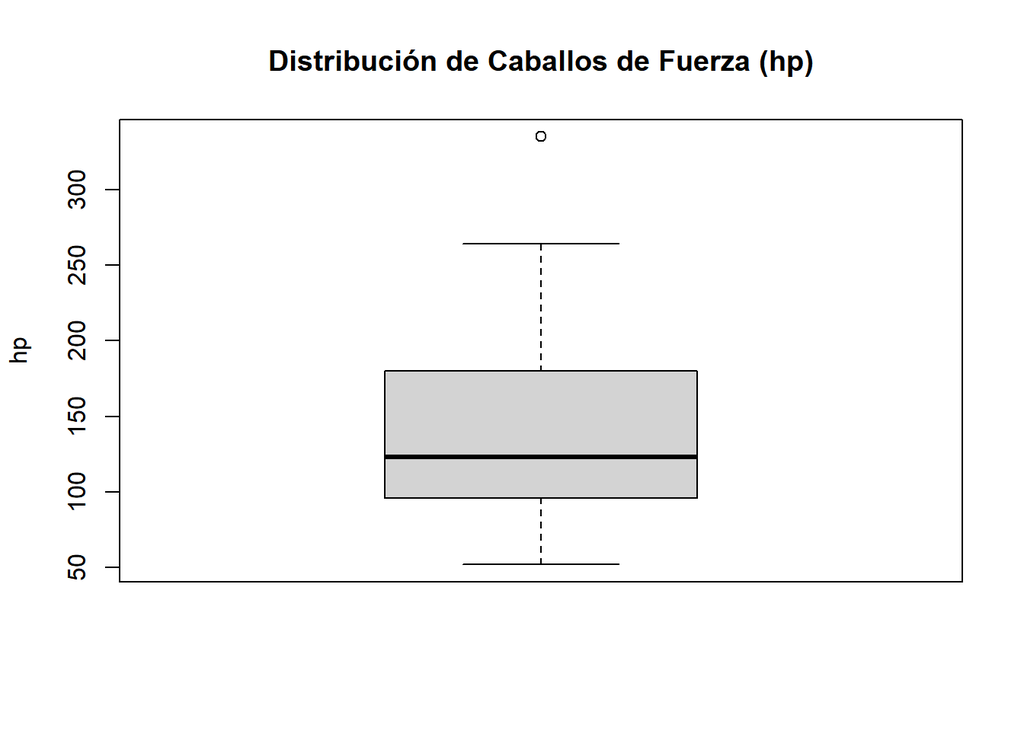

```r
# Boxplot de caballos de fuerza (hp)
boxplot(dt_mtcars$hp, main = "Distribución de Caballos de Fuerza (hp)", ylab = "hp")
```

**Explicación**: Un boxplot es útil para detectar autos que tienen una eficiencia de combustible muy diferente (valores atípicos) o autos con caballos de fuerza significativamente superiores o inferiores al promedio.

### 5.2 Violinplots: Combinando distribución y boxplot

Un **violinplot** combina un boxplot con una visualización de la distribución de los datos (similitud a un histograma). Nos ayuda a ver tanto la concentración de los datos como su rango.

Para usar violinplots, utilizamos `ggplot2`:

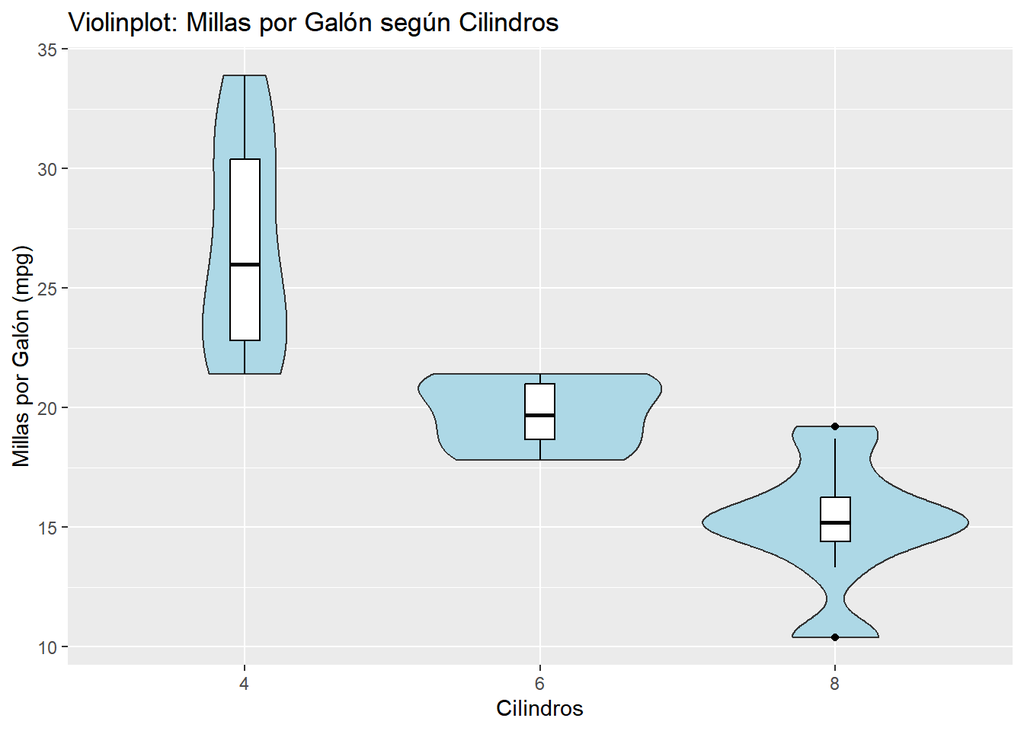

```r
# Instalar y cargar ggplot2 si no está instalado
# install.packages("ggplot2")
library(ggplot2)

# Crear un violinplot para mpg
ggplot(dt_mtcars, aes(x = factor(cyl), y = mpg)) +
  geom_violin(fill = "lightblue") +
  geom_boxplot(width = 0.1, color = "black", fill = "white") +
  labs(title = "Violinplot: Millas por Galón según Cilindros", x = "Cilindros", y = "Millas por Galón (mpg)")
```

**Explicación**: El violinplot muestra la distribución de `mpg` para automóviles con diferentes números de cilindros. Podemos observar dónde se concentran más los datos y si hay mucha variabilidad.

### 5.3 Histogramas para la distribución de datos

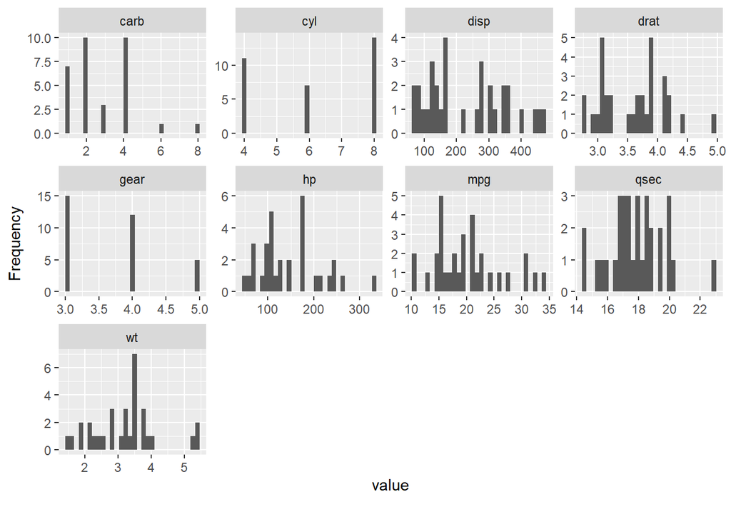

```r
# Histograma de millas por galón
plot_histogram(dt_mtcars)
```

**Explicación**: Un histograma es útil para ver cómo se distribuye una variable. Por ejemplo, si `mpg` se distribuye normalmente o si hay una asimetría en la distribución.

## 6. Ejercicios Prácticos

### **Ejercicio 1**: Estadísticas Descriptivas

Calcula la media, mediana y desviación estándar de la variable `hp` (caballos de fuerza) del conjunto de datos `mtcars`.

```r
# Tu código aquí
```

**Mostrar solución**

```r
# Solución
estadisticas_hp <- dt_mtcars[, .(
  Media_hp = mean(hp),
  Mediana_hp = median(hp),
  Desviacion_hp = sd(hp)
)]
print(estadisticas_hp)
```

```
##    Media_hp Mediana_hp Desviacion_hp
##       <num>      <num>         <num>
## 1: 146.6875        123      68.56287
```

### **Ejercicio 2**: Correlación entre Variables

Calcula la correlación entre `mpg` (millas por galón) y `wt` (peso del automóvil) en `mtcars`.

```r
# Tu código aquí
```

**Mostrar solución**

```r
# Solución
correlacion_mpg_wt <- cor(dt_mtcars$mpg, dt_mtcars$wt)
print(correlacion_mpg_wt)
```

```
## [1] -0.8676594
```